# SVA

Michael Hunt

April 4, 2016

In this section we will use the sva function in the sva package and apply it to the following data:

```r
#source("https://bioconductor.org/biocLite.R")
#biocLite("sva")

library(sva)
library(Biobase)
library(GSE5859Subset)
data(GSE5859Subset)
```

### SVA Exercises #1

In the previous section we estimated factors using PCA. But we noted that the first factor was correlated with our outcome of interest:

```r
s <- svd(geneExpression-rowMeans(geneExpression))
cor(sampleInfo$group,s$v[,1])
```

```
## [1] 0.6236858
```

As in the previous questions we are interested in finding genes that are differentially expressed between the two groups (males and females in this case). Here we learn to use SVA to estimate these effects while using a factor analysis approach to account for batch effects.

The `svafit` function estimates factors, but downweighting the genes that appear to correlate with the outcome of interest. It also tries to estimate the number of factors and returns the estimated factors like this:

```r
sex = sampleInfo$group
mod = model.matrix(~sex)
svafit = sva(geneExpression,mod)
```

```
## Number of significant surrogate variables is:  5
## Iteration (out of 5 ):1  2  3  4  5
```

```r
head(svafit$sv)
```

```
##             [,1]        [,2]        [,3]       [,4]         [,5]
## [1,] -0.26862626 -0.03838109 -0.15306742  0.3007374 -0.210098159
## [2,] -0.06132157 -0.15755769  0.03538763 -0.0851655  0.063869257
## [3,] -0.12161818 -0.21766433  0.12624414 -0.2443445  0.099004174
## [4,]  0.30660574 -0.09657648  0.32034135  0.1680430 -0.620260643
## [5,] -0.01850853  0.18648507 -0.17931970 -0.4244993  0.007840835
## [6,]  0.36062840 -0.08542758  0.10726746 -0.1074114 -0.033204590
```

Note that the resulting estimated factors are not that different from the PCs

```r
for(i in 1:ncol(svafit$sv)){
  print( cor(s$v[,i],svafit$sv[,i]) )
}
```

```
## [1] 0.9944755
## [1] 0.9964202
## [1] 0.9915972
## [1] 0.9896597
## [1] 0.9518427
```

Now fit a linear model to estimate the difference between males and females for each gene but that instead accounting for batch effects using month it includes the factors estimated by sva in the model. Use the qvalue function to estimate q-values.

How many genes have q-value < 0.1?

```r
svaX<-model.matrix(~sex+svafit$sv)

library(limma)
fit <- lmFit(geneExpression,svaX)
k <- 2 #second coef, for sex
ses <- fit$stdev.unscaled[,k]*fit$sigma
ttest <- fit$coef[,k]/ses
pvals <- 2*pt(-abs(ttest),fit$df)

library(qvalue)
library(genefilter)
qval = qvalue(pvals)
qvals = qval$qvalues
sum(qvals<0.1)
```

```
## [1] 13
```

What proportion of the genes are on chrX and chrY?

```r
index = geneAnnotation$CHR[qvals<0.1]%in%c("chrX","chrY")
mean(index)
```

```
## [1] 0.9230769
```

Remember that we should always perform exploratory data analysis to check problems. For example, before reporting this list of genes we could look at a volcano plot like this

```r
res = sapply(1:nrow(geneExpression),function(i){
    y = geneExpression[i,]
    fit = lm(y~svaX-1)
    summary(fit)$coef[2,c(1,4)]
})

qvals = qvalue(res[2,])$qvalue
pcutoff = max( res[2,qvals < .1] )
library(rafalib)
```

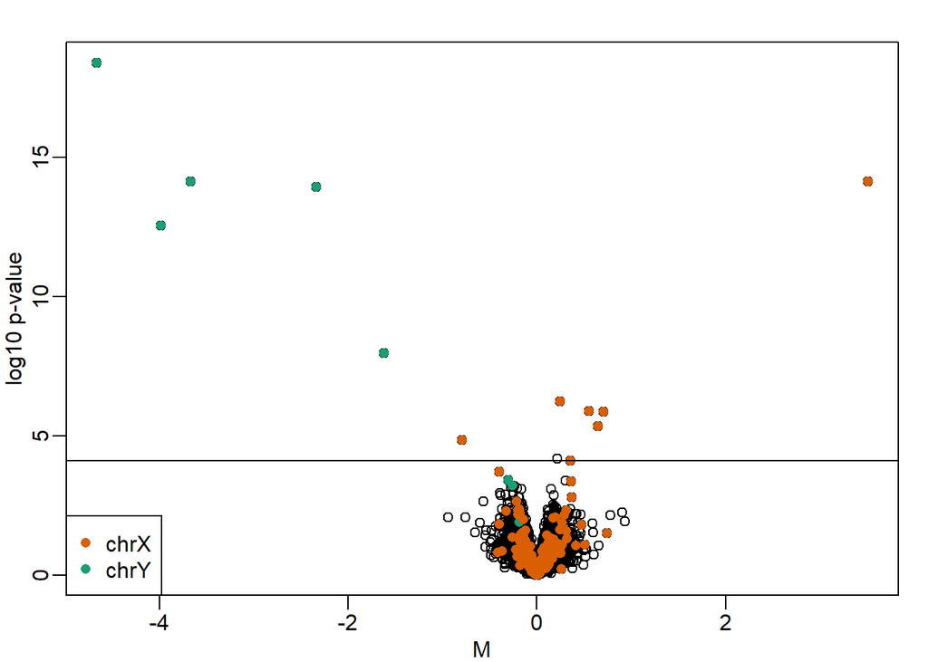

```r
mypar(1,1)

plot(res[1,],-log10(res[2,]),xlab="M",ylab="log10 p-value")

ind = which(geneAnnotation$CHR=="chrY")
points(res[1,ind],-log10(res[2,ind]),col=1,pch=16)

ind = which(geneAnnotation$CHR=="chrX")
points(res[1,ind],-log10(res[2,ind]),col=2,pch=16)

abline(h=-log10(pcutoff))
legend("bottomleft",c("chrX","chrY"),col=c(2,1),pch=16)
```

Note that there are six genes (five on chrY and one on chrX) that stand out as having large effects and small q-values.